# fancy graphs (post R)

Kosmas Hench

February 3, 2018

R and especially the **ggplot2** package are powerful tools for plotting your data. Although they allow for pretty good looking graphs, sometimes you might want to polish your plots even further. One example here is the map/pie chart plot where you can run into issues where one pie chart is obscured by another.

So, for situations like this one can turn to [**Inkscape**](https://inkscape.org/en/). This is a *free* and *open source* program for creating *vector graphics*. **Inkscape** might seem a little awkward at first, but it is a very powerful program. So in the beginning using the program might be a little painful - but in my experience it pays off later…

### *vector graphics* vs. *raster graphics*

Before we can start with our introduction to **Inkscape** I want to clarify the difference between *vector graphics* and *raster graphics*:

#### *raster graphics*:

You are probably familiar with several types of *raster graphics* already: These include *.bmp* (raw),*.jpg* (compressed) and *.png* (including transparency) files.

All those images are based on **pixels**. So, here the file stores the resolution of the image (*x* pixels wide and *y* pixels high) and a color value for each pixel within the image. Your image is basically a **map of pixels**.

The image quality (as well as the file size) is dependent on the *resolution* (the number of pixels). But no matter how high the quality of the image, if you continue to zoom in, at some point your image will become pixelated:

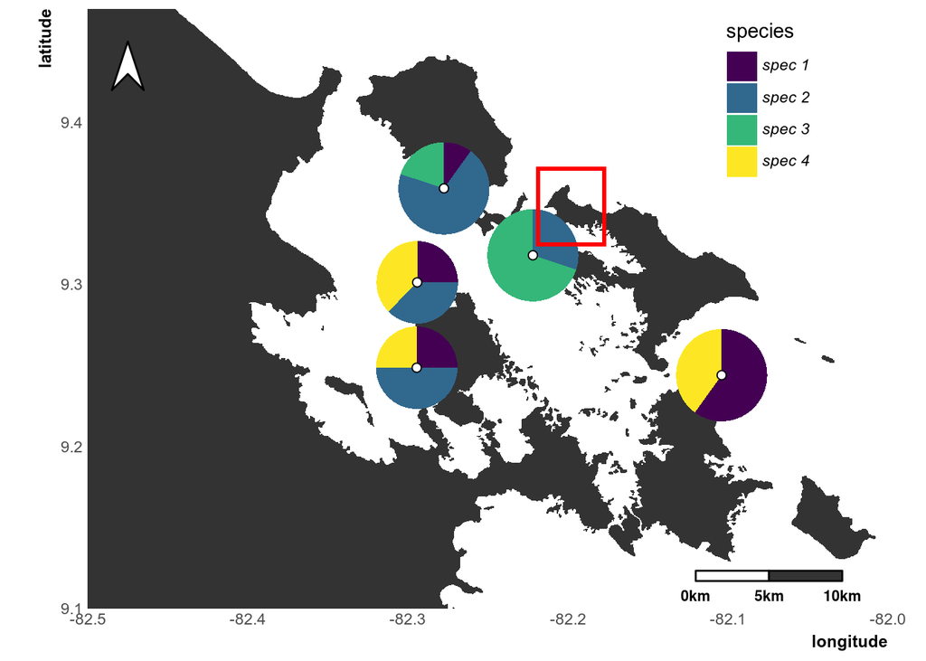

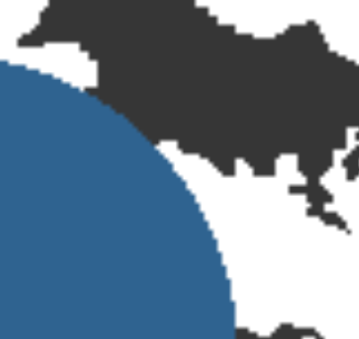

zoom on a raster graphic (index.png)

#### *vector graphics*:

In contrast to *raster graphics*, *vector graphics* don’t store information about pixels. One type of *vector graphic* that you already know are *.pdf* files, the most basic type are *.svg* files.

Since *vector graphics* do not store information about pixels, they also do not have an resolution. The best way to think of a *vector graphic* is to imagine them as a kind of coordinate system. Take a quick look at this example:

[figure not shown]

example of a .svg image

In this file the aspect ratio (200/100) would be stored. Furthermore, the file includes the information that we have a gray rectangle that starts at (0/0) and ends at (200/100) as well a circle with its center at (100/50) and a diameter of (50).

This is how such a file looks:

```html
<svg
   xmlns:rdf="http://www.w3.org/1999/02/22-rdf-syntax-ns#"
   xmlns:svg="http://www.w3.org/2000/svg"
   xmlns="http://www.w3.org/2000/svg"
   width="20mm"
   height="10mm"
   viewBox="0 0 200 100"
   id="svg">
  <defs
     id="defs4" />

    <rect
       style="fill:#cccccc"
       width="200"
       height="100"
       x="0"
       y="0" />
    <circle
       cx="100"
       cy="50"
       r="25" />
</svg>
```

If you want to test this, you can copy the code, paste it in a plain text editor and save it as “test.svg”. If you than open that file with a browser, you should see the image above.

In principle, the beauty of *vector graphics* is that they are always *crisp* and never pixelated. This is because, when you zoom on a *vector* image the computer is able to recalculate the zoomed part and redraw it.

So you can store images in perfect quality that usually are much smaller than a high quality *raster image*.

[figure not shown]

There is one exception to this though: If you have a very large number of points (eg. in the plots of genomic data that I showed in the two seminars) every point has to be stored in the *vector* file. This is also true for overlapping points which can make the image very large and will also make it load very slowly on your computer.

In that case it might be preferable to save the image as high resolution *raster graphic*.

In summary the difference between a *raster* and a *vector* graphic is that one stores **pixels** while the other stores **objects**.

### In R

Let’s quickly create a nice figure in R:

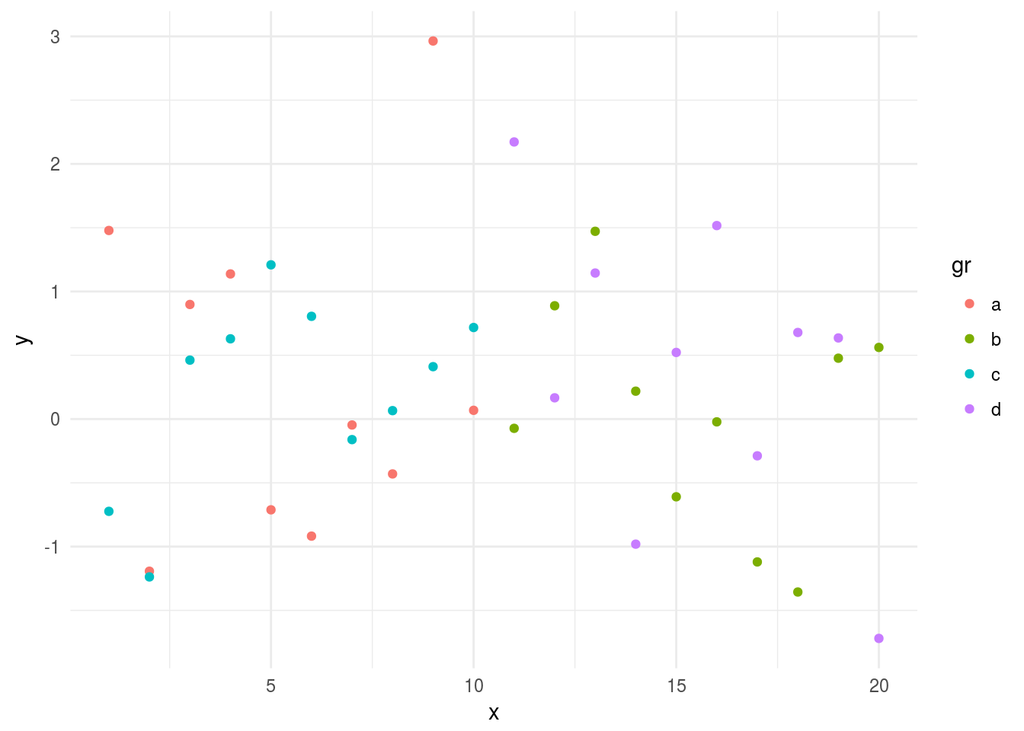

```r
library(ggplot2)
data <- data.frame(x=rep(1:20,2),y=rnorm(40),gr=rep(letters[c(1:4)],each=10))
ggplot(data,aes(x=x,y=y,col=gr))+
  geom_point()+
  theme_minimal()
```

We can save this as *vector* graphic as follows:

```r
ggsave("test.pdf",width = 10,height = 6)
```

This command will save the image as *test.pdf* in the current working directory of your R session. And from here **Inkscape** takes over the plot…

### Inkscape

To open the image in **Inkscape**, go to the folder that you saved the figure in. There you right-click the image and select *open with* and choose **Inkscape** (which of course you installed before).

The opening settings will pop up - make sure to uncheck the *replacing fonts* part:

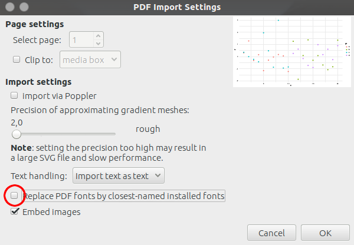

opening a .pdf file with **Inkscape** g)